# Metadatos ICFES

icfes: competencia: - interpretacion_representacion # Valores posibles: interpretacion_representacion, formulacion_ejecucion, argumentacion nivel_dificultad: 2 # Valores posibles: 1, 2, 3, 4 contenido: categoria: estadistica # Valores posibles: algebra_calculo, geometria, estadistica tipo: generico # Valores posibles: generico, no_generico contexto: laboral # Valores posibles: familiar, laboral, comunitario, matematico eje_axial: eje1 # Valores posibles: eje1, eje2, eje3, eje4 componente: aleatorio # Valores posibles: geometrico_metrico, numerico_variacional, aleatorio

# Question

Al momento de realizar un viaje por carretera, un conductor de empresa registró los siguientes parámetros durante su recorrido en la siguiente tabla:

| Tiempo (horas) | Costo del viaje (miles de pesos) | Combustible disponible (litros) | Distancia recorrida (kilómetros) |
| --- | --- | --- | --- |
| 0 | 0 | 54 | 0 |
| 2 | 28 | 40 | 15 |
| 4 | 43 | 21 | 37 |
| 6 | 59 | 13 | 61 |
| 8 | 97 | 3 | 76 |

De acuerdo con la tabla, la gráfica que representa CORRECTAMENTE el comportamiento de la distancia recorrida y el combustible disponible en función del tiempo es:

## Answerlist

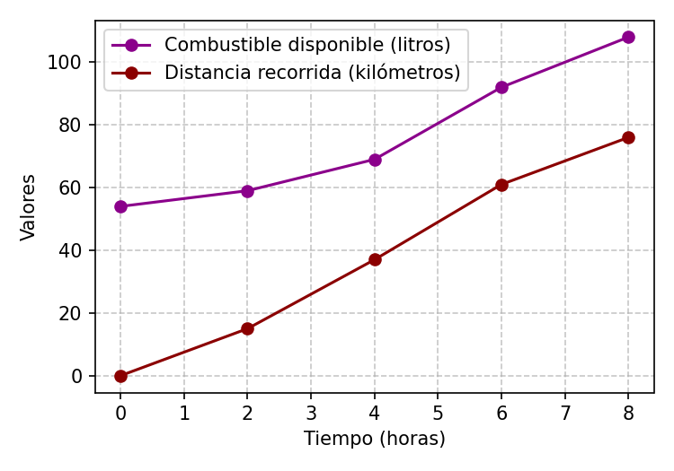

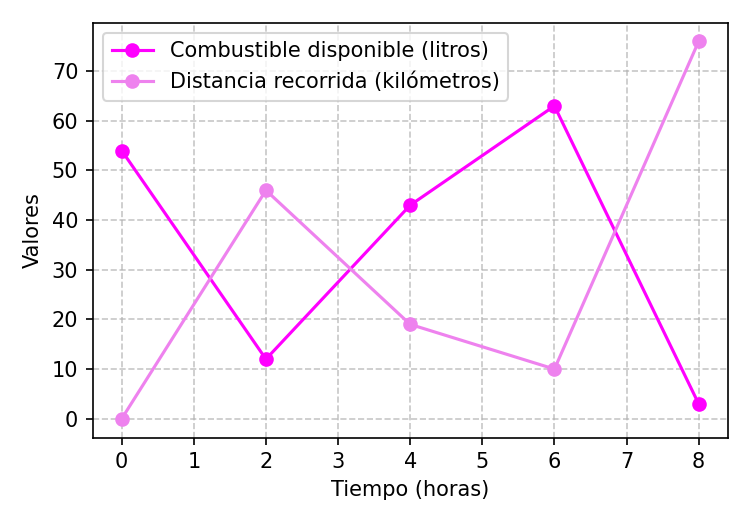

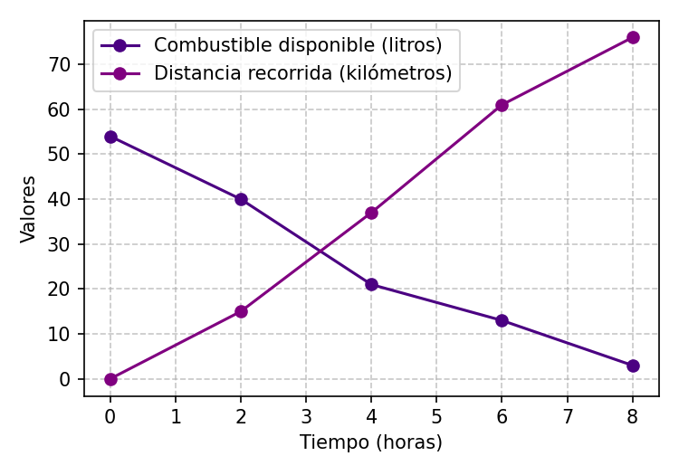

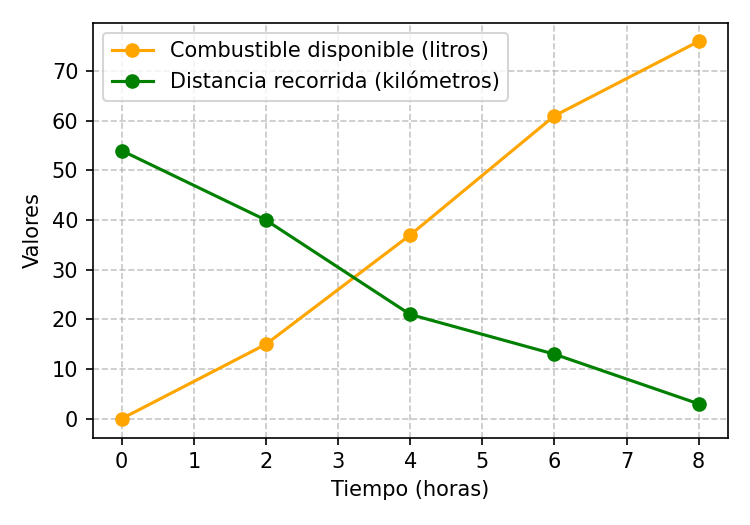

# Solution

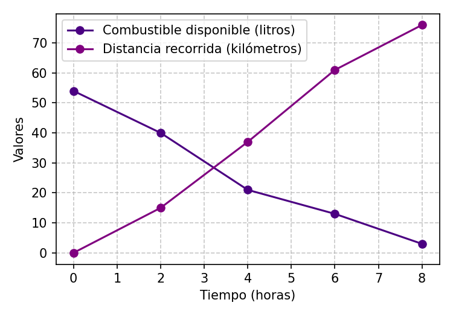

La gráfica correcta debe mostrar:

1. El combustible disponible disminuyendo con el tiempo, empezando en 54 litros y terminando en 3 litros.
2. La distancia recorrida aumentando con el tiempo, empezando en 0 km y llegando a 76 km.

Analizando los datos de la tabla, vemos que mientras el tiempo aumenta:

- El combustible disponible disminuye constantemente
- La distancia recorrida aumenta constantemente

## Answerlist

- Falso
- Falso
- Verdadero
- Falso

# Meta-information

exname: Interpretación de gráficas de combustible y distancia extype: schoice exsolution: 0010 exshuffle: TRUE exsection: Interpretación de gráficas